# Optimal Treatment Analysis

## Outcome Variable

**Outcome Variable:** haz

## Predictor Variables

**Intervention Variable:** predfeed6

**Adjustment Set:**

- arm
- sex
- month
- brthmon
- W_mage
- meducyrs
- feducyrs
- hhwealth_quart
- hfoodsec
- W_mhtcm
- vagbrth
- W_gagebrth
- W_birthwt
- W_birthlen
- W_nrooms
- W_nchldlt5
- W_parity
- impfloor
- impsan
- safeh20
- delta_W_mage
- delta_meducyrs
- delta_feducyrs
- delta_hhwealth_quart
- delta_hfoodsec
- delta_W_mhtcm
- delta_vagbrth
- delta_W_gagebrth
- delta_W_birthwt
- delta_W_birthlen
- delta_W_nrooms
- delta_W_nchldlt5
- delta_W_parity
- delta_impfloor
- delta_impsan
- delta_safeh20

## Stratifying Variables

The analysis was stratified on these variable(s):

- agecat
- studyid
- country

## Data Summary

| agecat | studyid | country | predfeed6 | n_cell | n |
| --- | --- | --- | --- | --- | --- |
| Birth | ki0047075b-MAL-ED | BANGLADESH | 1 | 119 | 231 |
| Birth | ki0047075b-MAL-ED | BANGLADESH | 0 | 112 | 231 |
| Birth | ki0047075b-MAL-ED | BRAZIL | 1 | 27 | 175 |
| Birth | ki0047075b-MAL-ED | BRAZIL | 0 | 148 | 175 |
| Birth | ki0047075b-MAL-ED | INDIA | 1 | 15 | 190 |
| Birth | ki0047075b-MAL-ED | INDIA | 0 | 175 | 190 |
| Birth | ki0047075b-MAL-ED | NEPAL | 1 | 23 | 170 |
| Birth | ki0047075b-MAL-ED | NEPAL | 0 | 147 | 170 |
| Birth | ki0047075b-MAL-ED | PERU | 1 | 106 | 256 |
| Birth | ki0047075b-MAL-ED | PERU | 0 | 150 | 256 |
| Birth | ki0047075b-MAL-ED | SOUTH AFRICA | 1 | 3 | 211 |
| Birth | ki0047075b-MAL-ED | SOUTH AFRICA | 0 | 208 | 211 |
| Birth | ki0047075b-MAL-ED | TANZANIA, UNITED REPUBLIC OF | 1 | 1 | 119 |
| Birth | ki0047075b-MAL-ED | TANZANIA, UNITED REPUBLIC OF | 0 | 118 | 119 |
| Birth | ki1000109-EE | PAKISTAN | 1 | 1 | 2 |
| Birth | ki1000109-EE | PAKISTAN | 0 | 1 | 2 |
| Birth | kiGH5241-JiVitA-3 | BANGLADESH | 1 | 15096 | 19082 |
| Birth | kiGH5241-JiVitA-3 | BANGLADESH | 0 | 3986 | 19082 |
| Birth | kiGH5241-JiVitA-4 | BANGLADESH | 1 | 619 | 767 |
| Birth | kiGH5241-JiVitA-4 | BANGLADESH | 0 | 148 | 767 |
| 6 months | ki0047075b-MAL-ED | BANGLADESH | 1 | 123 | 235 |
| 6 months | ki0047075b-MAL-ED | BANGLADESH | 0 | 112 | 235 |
| 6 months | ki0047075b-MAL-ED | BRAZIL | 1 | 35 | 209 |
| 6 months | ki0047075b-MAL-ED | BRAZIL | 0 | 174 | 209 |
| 6 months | ki0047075b-MAL-ED | INDIA | 1 | 18 | 232 |
| 6 months | ki0047075b-MAL-ED | INDIA | 0 | 214 | 232 |
| 6 months | ki0047075b-MAL-ED | NEPAL | 1 | 29 | 235 |
| 6 months | ki0047075b-MAL-ED | NEPAL | 0 | 206 | 235 |
| 6 months | ki0047075b-MAL-ED | PERU | 1 | 113 | 269 |
| 6 months | ki0047075b-MAL-ED | PERU | 0 | 156 | 269 |
| 6 months | ki0047075b-MAL-ED | SOUTH AFRICA | 1 | 3 | 242 |
| 6 months | ki0047075b-MAL-ED | SOUTH AFRICA | 0 | 239 | 242 |
| 6 months | ki0047075b-MAL-ED | TANZANIA, UNITED REPUBLIC OF | 1 | 2 | 244 |
| 6 months | ki0047075b-MAL-ED | TANZANIA, UNITED REPUBLIC OF | 0 | 242 | 244 |
| 6 months | ki1000109-EE | PAKISTAN | 1 | 218 | 372 |
| 6 months | ki1000109-EE | PAKISTAN | 0 | 154 | 372 |
| 6 months | ki1000304b-SAS-FoodSuppl | INDIA | 1 | 0 | 168 |
| 6 months | ki1000304b-SAS-FoodSuppl | INDIA | 0 | 168 | 168 |
| 6 months | ki1113344-GMS-Nepal | NEPAL | 1 | 404 | 546 |
| 6 months | ki1113344-GMS-Nepal | NEPAL | 0 | 142 | 546 |
| 6 months | ki1148112-LCNI-5 | MALAWI | 1 | 47 | 272 |
| 6 months | ki1148112-LCNI-5 | MALAWI | 0 | 225 | 272 |
| 6 months | kiGH5241-JiVitA-3 | BANGLADESH | 1 | 13223 | 16682 |
| 6 months | kiGH5241-JiVitA-3 | BANGLADESH | 0 | 3459 | 16682 |
| 6 months | kiGH5241-JiVitA-4 | BANGLADESH | 1 | 3332 | 4259 |
| 6 months | kiGH5241-JiVitA-4 | BANGLADESH | 0 | 927 | 4259 |
| 24 months | ki0047075b-MAL-ED | BANGLADESH | 1 | 112 | 209 |
| 24 months | ki0047075b-MAL-ED | BANGLADESH | 0 | 97 | 209 |
| 24 months | ki0047075b-MAL-ED | BRAZIL | 1 | 29 | 169 |
| 24 months | ki0047075b-MAL-ED | BRAZIL | 0 | 140 | 169 |
| 24 months | ki0047075b-MAL-ED | INDIA | 1 | 17 | 224 |
| 24 months | ki0047075b-MAL-ED | INDIA | 0 | 207 | 224 |
| 24 months | ki0047075b-MAL-ED | NEPAL | 1 | 28 | 227 |
| 24 months | ki0047075b-MAL-ED | NEPAL | 0 | 199 | 227 |
| 24 months | ki0047075b-MAL-ED | PERU | 1 | 84 | 198 |
| 24 months | ki0047075b-MAL-ED | PERU | 0 | 114 | 198 |
| 24 months | ki0047075b-MAL-ED | SOUTH AFRICA | 1 | 3 | 227 |
| 24 months | ki0047075b-MAL-ED | SOUTH AFRICA | 0 | 224 | 227 |
| 24 months | ki0047075b-MAL-ED | TANZANIA, UNITED REPUBLIC OF | 1 | 2 | 212 |
| 24 months | ki0047075b-MAL-ED | TANZANIA, UNITED REPUBLIC OF | 0 | 210 | 212 |
| 24 months | ki1113344-GMS-Nepal | NEPAL | 1 | 360 | 480 |
| 24 months | ki1113344-GMS-Nepal | NEPAL | 0 | 120 | 480 |
| 24 months | ki1148112-LCNI-5 | MALAWI | 1 | 34 | 189 |
| 24 months | ki1148112-LCNI-5 | MALAWI | 0 | 155 | 189 |
| 24 months | kiGH5241-JiVitA-3 | BANGLADESH | 1 | 6677 | 8542 |
| 24 months | kiGH5241-JiVitA-3 | BANGLADESH | 0 | 1865 | 8542 |
| 24 months | kiGH5241-JiVitA-4 | BANGLADESH | 1 | 3289 | 4174 |
| 24 months | kiGH5241-JiVitA-4 | BANGLADESH | 0 | 885 | 4174 |

The following strata were considered:

- agecat: 24 months, studyid: ki0047075b-MAL-ED, country: BANGLADESH
- agecat: 24 months, studyid: ki0047075b-MAL-ED, country: BRAZIL
- agecat: 24 months, studyid: ki0047075b-MAL-ED, country: INDIA
- agecat: 24 months, studyid: ki0047075b-MAL-ED, country: NEPAL
- agecat: 24 months, studyid: ki0047075b-MAL-ED, country: PERU
- agecat: 24 months, studyid: ki0047075b-MAL-ED, country: SOUTH AFRICA
- agecat: 24 months, studyid: ki0047075b-MAL-ED, country: TANZANIA, UNITED REPUBLIC OF
- agecat: 24 months, studyid: ki1113344-GMS-Nepal, country: NEPAL
- agecat: 24 months, studyid: ki1148112-LCNI-5, country: MALAWI
- agecat: 24 months, studyid: kiGH5241-JiVitA-3, country: BANGLADESH
- agecat: 24 months, studyid: kiGH5241-JiVitA-4, country: BANGLADESH
- agecat: 6 months, studyid: ki0047075b-MAL-ED, country: BANGLADESH
- agecat: 6 months, studyid: ki0047075b-MAL-ED, country: BRAZIL
- agecat: 6 months, studyid: ki0047075b-MAL-ED, country: INDIA
- agecat: 6 months, studyid: ki0047075b-MAL-ED, country: NEPAL
- agecat: 6 months, studyid: ki0047075b-MAL-ED, country: PERU
- agecat: 6 months, studyid: ki0047075b-MAL-ED, country: SOUTH AFRICA
- agecat: 6 months, studyid: ki0047075b-MAL-ED, country: TANZANIA, UNITED REPUBLIC OF
- agecat: 6 months, studyid: ki1000109-EE, country: PAKISTAN
- agecat: 6 months, studyid: ki1000304b-SAS-FoodSuppl, country: INDIA
- agecat: 6 months, studyid: ki1113344-GMS-Nepal, country: NEPAL
- agecat: 6 months, studyid: ki1148112-LCNI-5, country: MALAWI
- agecat: 6 months, studyid: kiGH5241-JiVitA-3, country: BANGLADESH
- agecat: 6 months, studyid: kiGH5241-JiVitA-4, country: BANGLADESH
- agecat: Birth, studyid: ki0047075b-MAL-ED, country: BANGLADESH
- agecat: Birth, studyid: ki0047075b-MAL-ED, country: BRAZIL
- agecat: Birth, studyid: ki0047075b-MAL-ED, country: INDIA
- agecat: Birth, studyid: ki0047075b-MAL-ED, country: NEPAL
- agecat: Birth, studyid: ki0047075b-MAL-ED, country: PERU
- agecat: Birth, studyid: ki0047075b-MAL-ED, country: SOUTH AFRICA
- agecat: Birth, studyid: ki0047075b-MAL-ED, country: TANZANIA, UNITED REPUBLIC OF
- agecat: Birth, studyid: ki1000109-EE, country: PAKISTAN
- agecat: Birth, studyid: kiGH5241-JiVitA-3, country: BANGLADESH
- agecat: Birth, studyid: kiGH5241-JiVitA-4, country: BANGLADESH

### Dropped Strata

Some strata were dropped due to rare outcomes:

- agecat: Birth, studyid: ki0047075b-MAL-ED, country: SOUTH AFRICA
- agecat: Birth, studyid: ki0047075b-MAL-ED, country: TANZANIA, UNITED REPUBLIC OF
- agecat: Birth, studyid: ki1000109-EE, country: PAKISTAN
- agecat: 6 months, studyid: ki0047075b-MAL-ED, country: SOUTH AFRICA
- agecat: 6 months, studyid: ki0047075b-MAL-ED, country: TANZANIA, UNITED REPUBLIC OF
- agecat: 6 months, studyid: ki1000304b-SAS-FoodSuppl, country: INDIA
- agecat: 24 months, studyid: ki0047075b-MAL-ED, country: SOUTH AFRICA
- agecat: 24 months, studyid: ki0047075b-MAL-ED, country: TANZANIA, UNITED REPUBLIC OF

## Methods Detail

We’re interested in the causal parameters $E[Y_a]$ for all values of $a \in \mathcal{A}$. These parameters represent the mean outcome if, possibly contrary to fact, we intervened to set all units to have $A=a$. Under the randomization and positivity assumptions, these are identified by the statistical parameters $\psi_a=E_W[E_{Y|A,W}(Y|A=a,W)]$. In addition, we’re interested in the mean of $Y$, $E[Y]$ under no intervention (the observed mean). We will estimate these parameters by using SuperLearner to fit the relevant likelihood factors – $E_{Y|A,W}(Y|A=a,W)$ and $p(A=a|W)$, and then updating our likelihood fit using a joint TMLE.

For unadjusted analyses ($W=\{\}$), initial likelihoods were estimated using Lrnr_glm to estimate the simple $E(Y|A)$ and Lrnr_mean to estimate $p(A)$. For adjusted analyses, a small library containing Lrnr_glmnet, Lrnr_xgboost, and Lrnr_mean was used.

Having estimated these parameters, we will then use the delta method to estimate relative risks and attributable risks relative to a prespecified baseline level of $A$.

# Results Detail

## Results Plots

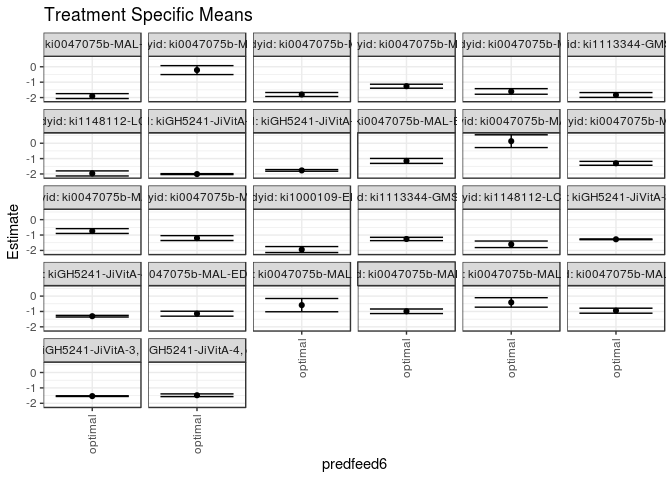

## Results Table

### Parameter: TSM

| agecat | studyid | country | intervention_level | baseline_level | estimate | ci_lower | ci_upper |
| --- | --- | --- | --- | --- | --- | --- | --- |
| Birth | ki0047075b-MAL-ED | BANGLADESH | optimal | observed | -1.1446589 | -1.3044063 | -0.9849116 |
| Birth | ki0047075b-MAL-ED | BRAZIL | optimal | observed | -0.5880285 | -1.0195666 | -0.1564904 |
| Birth | ki0047075b-MAL-ED | INDIA | optimal | observed | -0.9887654 | -1.1380078 | -0.8395230 |
| Birth | ki0047075b-MAL-ED | NEPAL | optimal | observed | -0.4116316 | -0.7192291 | -0.1040342 |
| Birth | ki0047075b-MAL-ED | PERU | optimal | observed | -0.9502983 | -1.1123693 | -0.7882273 |
| Birth | kiGH5241-JiVitA-3 | BANGLADESH | optimal | observed | -1.5338053 | -1.5570879 | -1.5105227 |
| Birth | kiGH5241-JiVitA-4 | BANGLADESH | optimal | observed | -1.4775431 | -1.5654600 | -1.3896261 |
| 6 months | ki0047075b-MAL-ED | BANGLADESH | optimal | observed | -1.1504616 | -1.3116588 | -0.9892644 |
| 6 months | ki0047075b-MAL-ED | BRAZIL | optimal | observed | 0.1323255 | -0.2825379 | 0.5471889 |
| 6 months | ki0047075b-MAL-ED | INDIA | optimal | observed | -1.3060484 | -1.4335385 | -1.1785584 |
| 6 months | ki0047075b-MAL-ED | NEPAL | optimal | observed | -0.7404831 | -0.8977889 | -0.5831773 |
| 6 months | ki0047075b-MAL-ED | PERU | optimal | observed | -1.1986421 | -1.3571216 | -1.0401626 |
| 6 months | ki1000109-EE | PAKISTAN | optimal | observed | -1.9440385 | -2.1378258 | -1.7502512 |
| 6 months | ki1113344-GMS-Nepal | NEPAL | optimal | observed | -1.2575581 | -1.3651767 | -1.1499394 |
| 6 months | ki1148112-LCNI-5 | MALAWI | optimal | observed | -1.6027797 | -1.8139916 | -1.3915678 |
| 6 months | kiGH5241-JiVitA-3 | BANGLADESH | optimal | observed | -1.2765819 | -1.3022986 | -1.2508652 |
| 6 months | kiGH5241-JiVitA-4 | BANGLADESH | optimal | observed | -1.3074964 | -1.3603877 | -1.2546051 |
| 24 months | ki0047075b-MAL-ED | BANGLADESH | optimal | observed | -1.9041569 | -2.0644369 | -1.7438769 |
| 24 months | ki0047075b-MAL-ED | BRAZIL | optimal | observed | -0.2144099 | -0.5046566 | 0.0758368 |
| 24 months | ki0047075b-MAL-ED | INDIA | optimal | observed | -1.8021216 | -1.9316168 | -1.6726264 |
| 24 months | ki0047075b-MAL-ED | NEPAL | optimal | observed | -1.2633144 | -1.3921205 | -1.1345082 |
| 24 months | ki0047075b-MAL-ED | PERU | optimal | observed | -1.6027884 | -1.7834574 | -1.4221194 |
| 24 months | ki1113344-GMS-Nepal | NEPAL | optimal | observed | -1.8334781 | -1.9906205 | -1.6763357 |
| 24 months | ki1148112-LCNI-5 | MALAWI | optimal | observed | -1.9642221 | -2.1300537 | -1.7983904 |
| 24 months | kiGH5241-JiVitA-3 | BANGLADESH | optimal | observed | -2.0059564 | -2.0356260 | -1.9762868 |
| 24 months | kiGH5241-JiVitA-4 | BANGLADESH | optimal | observed | -1.7682884 | -1.8212739 | -1.7153029 |

### Parameter: E(Y)

| agecat | studyid | country | intervention_level | baseline_level | estimate | ci_lower | ci_upper |
| --- | --- | --- | --- | --- | --- | --- | --- |
| Birth | ki0047075b-MAL-ED | BANGLADESH | observed | observed | -1.0317316 | -1.1618799 | -0.9015833 |
| Birth | ki0047075b-MAL-ED | BRAZIL | observed | observed | -0.7263429 | -0.8876385 | -0.5650472 |
| Birth | ki0047075b-MAL-ED | INDIA | observed | observed | -1.0250526 | -1.1724135 | -0.8776918 |
| Birth | ki0047075b-MAL-ED | NEPAL | observed | observed | -0.6964706 | -0.8552823 | -0.5376589 |
| Birth | ki0047075b-MAL-ED | PERU | observed | observed | -0.9311719 | -1.0458986 | -0.8164451 |
| Birth | kiGH5241-JiVitA-3 | BANGLADESH | observed | observed | -1.5502914 | -1.5696478 | -1.5309349 |
| Birth | kiGH5241-JiVitA-4 | BANGLADESH | observed | observed | -1.5207432 | -1.6058630 | -1.4356233 |
| 6 months | ki0047075b-MAL-ED | BANGLADESH | observed | observed | -1.2140355 | -1.3320337 | -1.0960372 |
| 6 months | ki0047075b-MAL-ED | BRAZIL | observed | observed | 0.0510207 | -0.0930194 | 0.1950608 |
| 6 months | ki0047075b-MAL-ED | INDIA | observed | observed | -1.2193606 | -1.3390323 | -1.0996890 |
| 6 months | ki0047075b-MAL-ED | NEPAL | observed | observed | -0.5595745 | -0.6727496 | -0.4463993 |
| 6 months | ki0047075b-MAL-ED | PERU | observed | observed | -1.3092999 | -1.4165606 | -1.2020392 |
| 6 months | ki1000109-EE | PAKISTAN | observed | observed | -2.2004704 | -2.3234073 | -2.0775336 |
| 6 months | ki1113344-GMS-Nepal | NEPAL | observed | observed | -1.3352045 | -1.4146382 | -1.2557708 |
| 6 months | ki1148112-LCNI-5 | MALAWI | observed | observed | -1.6395956 | -1.7592633 | -1.5199278 |
| 6 months | kiGH5241-JiVitA-3 | BANGLADESH | observed | observed | -1.3104400 | -1.3338132 | -1.2870668 |
| 6 months | kiGH5241-JiVitA-4 | BANGLADESH | observed | observed | -1.3574771 | -1.3964060 | -1.3185482 |
| 24 months | ki0047075b-MAL-ED | BANGLADESH | observed | observed | -1.9532775 | -2.0781247 | -1.8284303 |
| 24 months | ki0047075b-MAL-ED | BRAZIL | observed | observed | 0.0418343 | -0.1253834 | 0.2090521 |
| 24 months | ki0047075b-MAL-ED | INDIA | observed | observed | -1.8466071 | -1.9736347 | -1.7195796 |
| 24 months | ki0047075b-MAL-ED | NEPAL | observed | observed | -1.2744493 | -1.3952297 | -1.1536689 |
| 24 months | ki0047075b-MAL-ED | PERU | observed | observed | -1.7294949 | -1.8488722 | -1.6101177 |
| 24 months | ki1113344-GMS-Nepal | NEPAL | observed | observed | -1.8951389 | -1.9810871 | -1.8091907 |
| 24 months | ki1148112-LCNI-5 | MALAWI | observed | observed | -1.9605820 | -2.1001715 | -1.8209925 |
| 24 months | kiGH5241-JiVitA-3 | BANGLADESH | observed | observed | -2.0122091 | -2.0399540 | -1.9844641 |
| 24 months | kiGH5241-JiVitA-4 | BANGLADESH | observed | observed | -1.7762003 | -1.8148628 | -1.7375378 |

### Parameter: PAR

| agecat | studyid | country | intervention_level | baseline_level | estimate | ci_lower | ci_upper |
| --- | --- | --- | --- | --- | --- | --- | --- |
| Birth | ki0047075b-MAL-ED | BANGLADESH | optimal | observed | 0.1129273 | -0.0162450 | 0.2420997 |
| Birth | ki0047075b-MAL-ED | BRAZIL | optimal | observed | -0.1383144 | -0.5335662 | 0.2569374 |
| Birth | ki0047075b-MAL-ED | INDIA | optimal | observed | -0.0362873 | -0.0917340 | 0.0191595 |
| Birth | ki0047075b-MAL-ED | NEPAL | optimal | observed | -0.2848390 | -0.5718335 | 0.0021555 |
| Birth | ki0047075b-MAL-ED | PERU | optimal | observed | 0.0191264 | -0.1007392 | 0.1389920 |
| Birth | kiGH5241-JiVitA-3 | BANGLADESH | optimal | observed | -0.0164861 | -0.0294971 | -0.0034750 |
| Birth | kiGH5241-JiVitA-4 | BANGLADESH | optimal | observed | -0.0432001 | -0.0817660 | -0.0046342 |
| 6 months | ki0047075b-MAL-ED | BANGLADESH | optimal | observed | -0.0635739 | -0.1784836 | 0.0513358 |
| 6 months | ki0047075b-MAL-ED | BRAZIL | optimal | observed | -0.0813047 | -0.4502010 | 0.2875915 |
| 6 months | ki0047075b-MAL-ED | INDIA | optimal | observed | 0.0866878 | 0.0070766 | 0.1662990 |
| 6 months | ki0047075b-MAL-ED | NEPAL | optimal | observed | 0.1809086 | 0.0824096 | 0.2794077 |
| 6 months | ki0047075b-MAL-ED | PERU | optimal | observed | -0.1106578 | -0.2365495 | 0.0152340 |
| 6 months | ki1000109-EE | PAKISTAN | optimal | observed | -0.2564320 | -0.4068990 | -0.1059649 |
| 6 months | ki1113344-GMS-Nepal | NEPAL | optimal | observed | -0.0776464 | -0.1543035 | -0.0009894 |
| 6 months | ki1148112-LCNI-5 | MALAWI | optimal | observed | -0.0368159 | -0.2029971 | 0.1293653 |
| 6 months | kiGH5241-JiVitA-3 | BANGLADESH | optimal | observed | -0.0338581 | -0.0451575 | -0.0225588 |
| 6 months | kiGH5241-JiVitA-4 | BANGLADESH | optimal | observed | -0.0499807 | -0.0893602 | -0.0106013 |
| 24 months | ki0047075b-MAL-ED | BANGLADESH | optimal | observed | -0.0491206 | -0.1830143 | 0.0847731 |
| 24 months | ki0047075b-MAL-ED | BRAZIL | optimal | observed | 0.2562443 | 0.0073153 | 0.5051732 |
| 24 months | ki0047075b-MAL-ED | INDIA | optimal | observed | -0.0444855 | -0.0878171 | -0.0011539 |
| 24 months | ki0047075b-MAL-ED | NEPAL | optimal | observed | -0.0111350 | -0.0572595 | 0.0349895 |
| 24 months | ki0047075b-MAL-ED | PERU | optimal | observed | -0.1267066 | -0.2697257 | 0.0163126 |
| 24 months | ki1113344-GMS-Nepal | NEPAL | optimal | observed | -0.0616607 | -0.1879172 | 0.0645957 |
| 24 months | ki1148112-LCNI-5 | MALAWI | optimal | observed | 0.0036401 | -0.1420196 | 0.1492997 |
| 24 months | kiGH5241-JiVitA-3 | BANGLADESH | optimal | observed | -0.0062527 | -0.0193738 | 0.0068684 |
| 24 months | kiGH5241-JiVitA-4 | BANGLADESH | optimal | observed | -0.0079119 | -0.0416807 | 0.0258569 |